# Unsupervised Learning on Simulated Spatial Data

Alex Li

June 14th, 2022

```r
datadir <- '~/UROP'
source(file.path(datadir, 'R/unsupervised.R'))
```

```
## Attaching SeuratObject
```

```r
source(file.path(datadir, 'R/analysis.R'))
```

## Introduction

As a proof-of-concept for our unsupervised model, we run the algorithm on a simulated cerebellum dataset. The dataset is generated using a snRNA reference dataset, where every pair of cell types exhibits a uniform distribution of mixing. Only two cell types are mixed at a time, and the default doublet mode of the algorithm is tested.

## Generating the simulated dataset

First, we generate the simulated dataset using the reference.

```r
sub_sample_cell <- function(gene_list, raw.data, cell_index, UMI_sample) {
  sub_sample = sample(rep(rownames(raw.data),raw.data[,cell_index]),UMI_sample,replace=FALSE)
  sub_sample = table(sub_sample)[as.character(gene_list)]
  names(sub_sample) = gene_list
  sub_sample[is.na(sub_sample)] <- 0
  return(sub_sample)
}

generate_sim_puck <- function(common_cell_types, gene_list, ref, trials = 30, UMI_tot = 1000) {
  n_cell_types = length(common_cell_types)
  n_conditions = 13
  boundary = ceiling(n_conditions / 2)
  N_samples = (n_cell_types * trials * n_conditions * (n_cell_types - 1))/2 # total number of samples
  first_UMI = numeric(N_samples); first_type = character(N_samples); second_type = character(N_samples)
  # first_UMI, first_type, second_type are all vectors of length N_samples. first_type, second_type store cell types,
  # first_UMI stores UMI counts
  UMI_tot = UMI_tot; UMI_step = UMI_tot / (n_conditions-1)
  UMI_tot = round(UMI_step * (n_conditions-1)); UMI1_vec = round(0:(n_conditions-1)*UMI_step)
  # above are the UMI amounts
  beads = Matrix(0, nrow = length(gene_list), ncol = N_samples)
  rownames(beads) = gene_list; colnames(beads) = 1:N_samples
  # beads that are filled as the algorithm runs, only thing that has to change is N_samples
  firstbeads = Matrix(0, nrow = length(gene_list), ncol = N_samples)
  rownames(firstbeads) = gene_list; colnames(firstbeads) = 1:N_samples
  secbeads = Matrix(0, nrow = length(gene_list), ncol = N_samples)
  rownames(secbeads) = gene_list; colnames(secbeads) = 1:N_samples
  # firstbeads and secbeads add together to create beads
  first_index_list <- numeric(N_samples); second_index_list <- numeric(N_samples);
  names(first_index_list) <- 1:N_samples; names(second_index_list) <- 1:N_samples;
  index = 1
  nUMI = ref@nUMI
  results <- matrix(ncol = 4)
  for(i in 1:(n_cell_types-1)) {
    print(paste("Progress",i))
    for(j in (i+1):n_cell_types) {
      print(paste("ProgressSecond",j))
      type1 = common_cell_types[i]; type2 = common_cell_types[j]
      for (condition in 1:n_conditions) {
        UMI1 = UMI1_vec[condition]; UMI2 = UMI_tot - UMI1
        for(t in 1:trials) {
          first_UMI[index] = UMI1; first_type[index] = type1; second_type[index] = type2
          # sets UMI values and cell types
          firstInd = sample(intersect(which(ref@cell_types == type1) , which(nUMI > 1000)),1)
          secondInd = sample(intersect(which(ref@cell_types == type2) , which(nUMI > 1000)),1)
          # samples a reference barcode index for each cell type
          first_index_list[index] <- firstInd; second_index_list[index] <- secondInd
          # stores the barcode indices in the lists
          firstbeads[,index] = as.vector(sub_sample_cell(gene_list, ref@counts, firstInd, UMI1))
          secbeads[,index] = as.vector(sub_sample_cell(gene_list, ref@counts, secondInd, UMI2))
          beads[,index] = firstbeads[,index] + secbeads[,index]
          # samples gene counts using the UMI amounts and the barcode index from above
          results <- rbind(results, c(type1, type2, UMI1, UMI2))
          index = index + 1
        }
      }
    }
  }
  results <- results[-1,]
  results <- as.data.frame(results)
  return(list(beads = beads, results = results))
}

reference <- readRDS(file.path(datadir, '/data/reference_RCTD_vec.rds'))
cell_types <- c('Astrocytes', 'Bergmann', 'Fibroblast', 'Golgi', 'Granule', 'MLI1', 'MLI2', 'Oligodendrocytes', 'Polydendrocytes', 'Purkinje')
beads_list <- generate_sim_puck(cell_types, rownames(reference@counts), reference, trials=30)
beads <- beads_list$beads; results <- beads_list$results
puck <- SpatialRNA(NULL, beads, use_fake_coords = T)
saveRDS(puck, file.path(datadir, '/objects/vignette_v1/sim_puck.rds'))
saveRDS(results, file.path(datadir, '/objects/vignette_v1/sim_puck_truth.rds'))
```

## Running unsupervised learning

Now we run unsupervised learning on the simulated puck.

```r
puck <- readRDS(file.path(datadir, 'objects/vignette_v1/sim_puck.rds'))
cell_type_info <- initialize.clusters(puck, resolution = 0.135)
myRCTD <- create.object(puck, cell_type_info)
myRCTD <- run.algorithm(myRCTD, MIN_CHANGE = 1e-3)
saveRDS(myRCTD, file.path(datadir, 'objects/vignette_v1/sim_puck_new.rds'))
```

## Analyzing singlets

We load the data and look at the final iteration as our predicted results. We can begin by analyzing its singlet assignment accuracy.

```r
results <- readRDS(file.path(datadir, 'objects/vignette_v1/sim_puck_truth.rds'))
colnames(results) <- c('type1','type2','UMI1','UMI2')
RCTD_list <- readRDS(file.path(datadir, 'objects/vignette_v1/sim_puck_new.rds'))
RCTD_pred <- RCTD_list[[length(RCTD_list)]]
pred_results <- RCTD_pred@results$results_df

# analyze singlets
truth_types = c()
pred_types = c()
for (i in 1:dim(results)[1]) {
  if (pred_results[i,'spot_class'] == 'singlet' & strtoi(results[i,'UMI1']) > strtoi(results[i,'UMI2'])) {
    truth_types <- append(truth_types, results[i,'type1'])
    pred_types <- append(pred_types, RCTD_pred@results$results_df[i, 'first_type'])
  } else if (pred_results[i,'spot_class'] == 'singlet' & strtoi(results[i,'UMI2']) > strtoi(results[i,'UMI1'])) {
    truth_types <- append(truth_types, results[i,'type2'])
    pred_types <- append(pred_types, RCTD_pred@results$results_df[i, 'first_type'])
  }
}
mytable <- table(truth_types, pred_types)
mytable
```

```
##                   pred_types
## truth_types          0   1   2   3   4   5   6   7   8
##   Astrocytes         0   0   0   0   0   0 585   5   0
##   Bergmann           0   0   0   0   0   0   1 543   0
##   Fibroblast         0 389   0   0   0   0   0   0   0
##   Golgi              0   0   0   0   0   0   0   0 701
##   Granule            0   0   0 544   0   0   0   0   0
##   MLI1               0   0   0   0   0 668   0   0   0
##   MLI2               0   0   0   0   0 684   0   0   0
##   Oligodendrocytes 426   0   0   0   0   0   0   0   0
##   Polydendrocytes   42   0 537   0   0   0   0   0   0
##   Purkinje           0   0   0   0 463   0   0   0   0
```

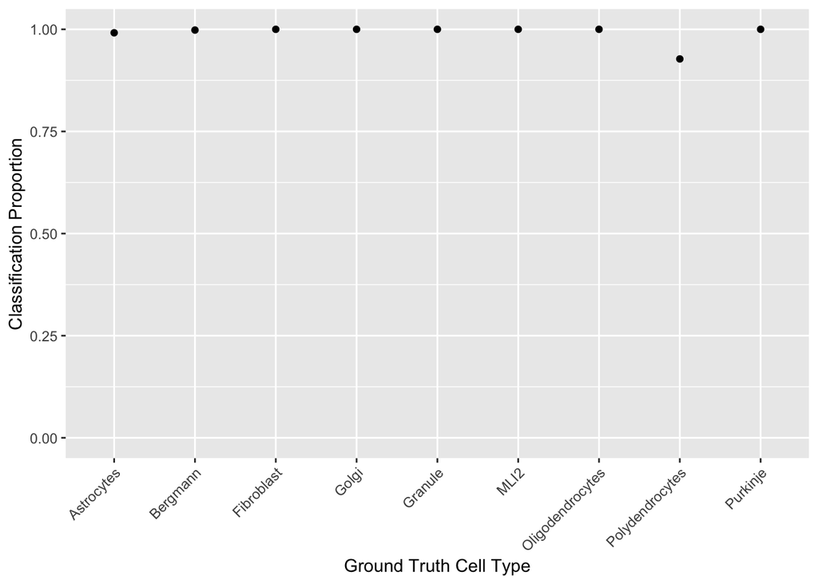

```r
assignment.accuracy.plot(mytable)
```

## Analyzing Purkinje-Bergmann doublets

Next, we will analyze doublets. Since Purkinje and Bergmann cells co-localize in the cerebellum, we will analyze these doublets.

```r
doublet_truth <- results[results$type1 == 'Bergmann' & results$type2 == 'Purkinje',]
doublet_pred <- pred_results[rownames(doublet_truth),]

deconvolved_doublets <- doublet_pred[(doublet_pred$spot_class == 'doublet_certain') &
                 ((doublet_pred$first_type == '7' & doublet_pred$second_type == '4') | (doublet_pred$first_type == '4' & doublet_pred$second_type == '7')),]
first_IDs <- rownames(deconvolved_doublets[deconvolved_doublets$first_type == '7',])
second_IDs <- rownames(deconvolved_doublets[deconvolved_doublets$second_type == '7',])

first_truth <- strtoi(doublet_truth[first_IDs, 'UMI1']) / 1000
second_truth <- strtoi(doublet_truth[second_IDs, 'UMI1']) / 1000
first_pred <- RCTD_pred@results$weights_doublet[first_IDs, 'first_type']
second_pred <- RCTD_pred@results$weights_doublet[second_IDs, 'second_type']

true_prop <- c(first_truth, second_truth)
pred_prop <- c(first_pred, second_pred)
```

```r
sqrt(sum((true_prop - pred_prop)^2) / length(true_prop))
```

```
## [1] 0.03659985
```

We can also plot the predicted Bergmann proportion as a function of the true Bergmann proportion.

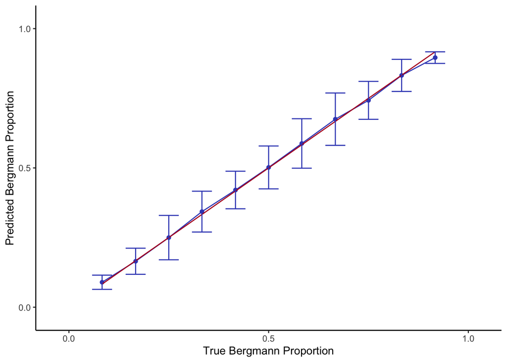

```r
prop_df <- data.frame(factor(true_prop), pred_prop)
true_proportions <- levels(prop_df$factor.true_prop.)
means <- c()
stdevs <- c()
for (prop in true_proportions) {
  means <- append(means, mean(prop_df[prop_df$factor.true_prop. == prop,]$pred_prop))
  stdevs <- append(stdevs, sd(prop_df[prop_df$factor.true_prop. == prop,]$pred_prop))
}
library(ggplot2)
results_df <- data.frame(as.numeric(true_proportions), means, stdevs)
colnames(results_df) <- c('true', 'means', 'stdev')
my_pal = pals::coolwarm(20)

p1 <-ggplot2::ggplot(results_df, ggplot2::aes(x=true, y=means, colour = "true")) +
  ggplot2::geom_line() +
  ggplot2::geom_point() +
  ggplot2::geom_line(ggplot2::aes(y=true,colour = "means")) +
  ggplot2::geom_errorbar(ggplot2::aes(ymin=means-1.96*stdevs, ymax=means+1.96*stdevs), width=.05,
                         position=ggplot2::position_dodge(0.05)) + theme_classic() + xlab('True Bergmann Proportion')+ ylab('Predicted Bergmann Proportion')+ scale_color_manual(values=c(my_pal[20], my_pal[1]),labels = c("",""), name = "") + scale_y_continuous(breaks = c(0,0.5,1), limits = c(-.03,1.03))+ scale_x_continuous(breaks = c(0,0.5,1), limits = c(-.03,1.03))+ theme(legend.position = "none")
p1
```

Next, we can analyze the rate at which pixels are being classified as doublets by the unsupervised algorithm.

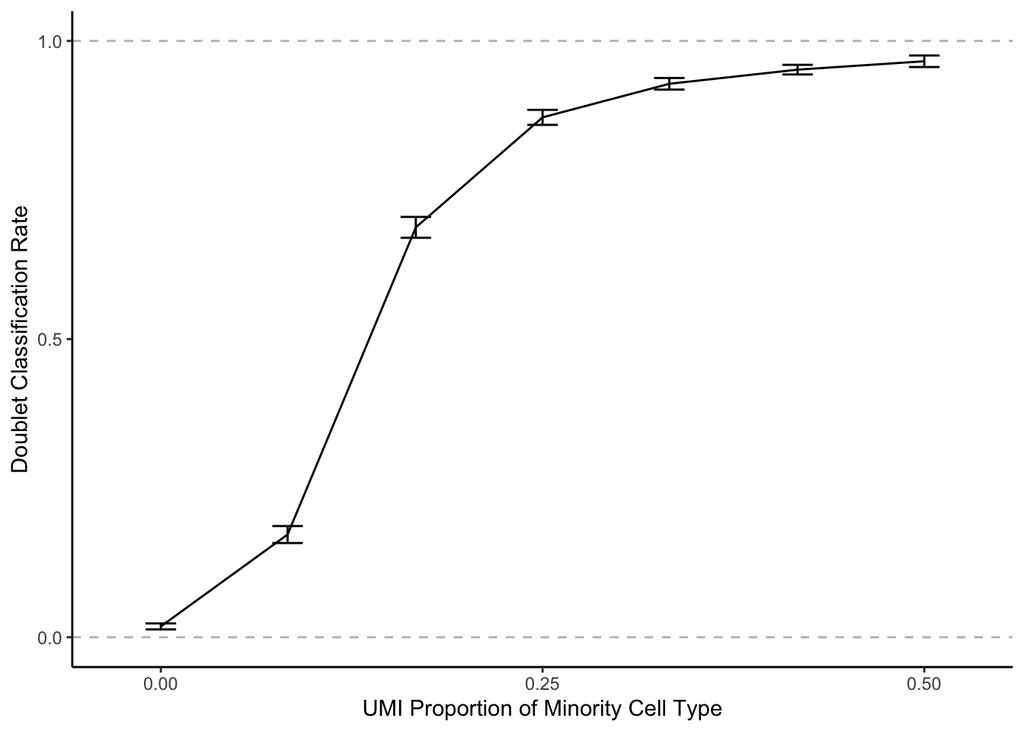

```r
doublets_pred <- pred_results[pred_results$spot_class == 'doublet_certain',] #results filtered for confident doublets
doublets_true <- results[rownames(doublets_pred),] #real proportions of predicted doublets
results$prop <- factor(strtoi(pmin(results$UMI1, results$UMI2)) / 1000) #real proportinos of all doublets
doublets_true$prop <- factor(strtoi(pmin(doublets_true$UMI1, doublets_true$UMI2)) / 1000, levels=levels(results$prop))
doublet_classification_rate <- table(doublets_true$prop) / table(results$prop)

doublet_df <- as.data.frame(doublet_classification_rate)
doublet_df$std <- sqrt(doublet_classification_rate * (1 - doublet_classification_rate) / table(results$prop))
colnames(doublet_df) <- c('prop', 'value', 'std')
doublet_df$prop <- as.numeric(levels(doublet_df$prop))

my_pal = pals::coolwarm(20)
p2 <- ggplot(doublet_df, aes(prop,value)) + geom_line()  +
  geom_errorbar(aes(ymin=value-1.96*std, ymax=value+1.96*std), width=.02,position=position_dodge(.001)) + theme_classic() +
  geom_hline(yintercept=0, linetype="dashed", color = "grey", size=0.5) + geom_hline(yintercept=1, linetype="dashed", color = "grey", size=0.5) + xlab("UMI Proportion of Minority Cell Type") + ylab("Doublet Classification Rate") + scale_color_manual(values=c(my_pal[1], my_pal[20]),labels = c("Doublet"), name = "Class") + scale_y_continuous(breaks = c(0,0.5,1), limits = c(0,1))+ scale_x_continuous(breaks = c(0,0.25,0.5), limits = c(-.03,0.53))
p2
```

## Analyzing marker genes

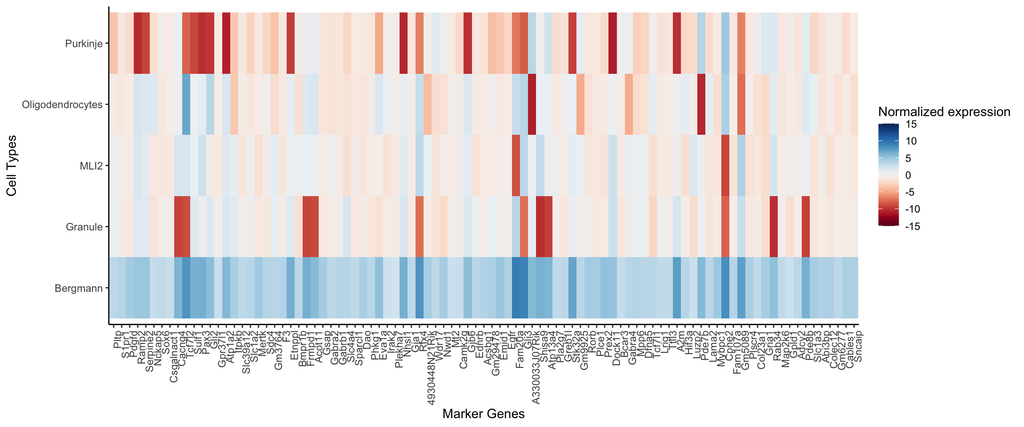

```r
cluster_assignments <- rownames(mytable)[apply(mytable, 2, function(x) which(x == max(x)))]
names(cluster_assignments) <- colnames(mytable)

marker_data_truth <- readRDS(file.path(datadir, 'Data/marker_data_de_standard.RDS'))
cell_type_info <- RCTD_pred@cell_type_info$info[[1]]
colnames(cell_type_info) <- cluster_assignments
markers <- rownames(marker_data_truth[marker_data_truth$cell_type == 'Bergmann',])
normalized_info <- apply(cell_type_info[intersect(rownames(cell_type_info), markers), c('Bergmann','Granule','MLI2','Oligodendrocytes','Purkinje')], MARGIN = 1, FUN = function(x) log(x) - mean(log(x)))

data <- melt(normalized_info)
ggplot(data, aes(factor(Var2), factor(Var1), fill= value)) +
    geom_tile() +
    theme_classic() +
    scale_fill_gradientn(colors = pals::brewer.rdbu(20)[1:20], limits=c(-15, 15)) +
    theme(axis.text.x = element_text(angle = 90, hjust = 1)) +
    xlab('Marker Genes')+ ylab('Cell Types') + labs(fill='Normalized expression')
```

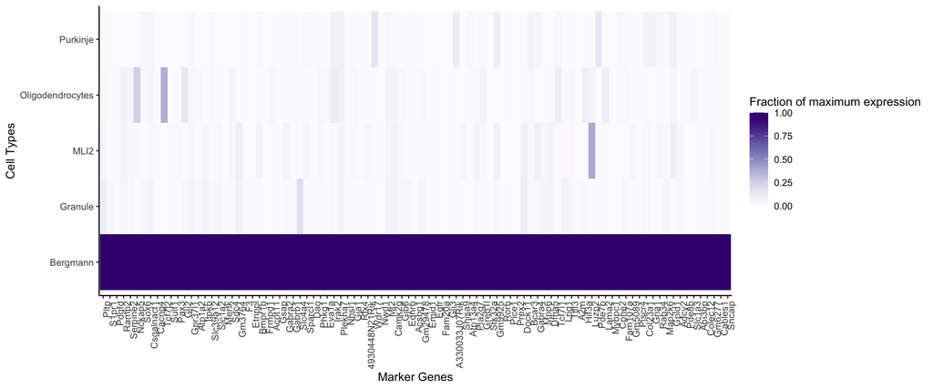

```r
normalized_info <- apply(cell_type_info[intersect(rownames(cell_type_info), markers), c('Bergmann','Granule','MLI2','Oligodendrocytes','Purkinje')], MARGIN = 1, FUN = function(x) x / max(x))

data <- melt(normalized_info)
ggplot(data, aes(factor(Var2), factor(Var1), fill= value)) +
    geom_tile() +
    theme_classic() +
    scale_fill_gradientn(colors = pals::brewer.purples(20)[1:20], limits=c(0,1)) +
    theme(axis.text.x = element_text(angle = 90, hjust = 1)) +
    xlab('Marker Genes')+ ylab('Cell Types') + labs(fill='Fraction of maximum expression')
```